# 2.exploration (exercises)

Joao Lopes

2025-12-16

# 1. VARIATION

[from https://r4ds.hadley.nz/EDA.html#variation]

[see https://jrnold.github.io/r4ds-exercise-solutions/exploratory-data-analysis.html]

[see https://mine-cetinkaya-rundel.github.io/r4ds-solutions/EDA.html]

```r
library("tidyverse")
```

## 1.1. TYPICAL VALUES

a) Explore the distribution of each of the x, y, and z variables in diamonds. What do you learn? Think about a diamond and how you might decide which dimension is the length, width, and depth.

```r
diamonds |>
  select(x, y, z) |>                   #select columns "x", "y", "z
  summary()                            #calculate summary statistics
```

```
##        x                y                z
##  Min.   : 0.000   Min.   : 0.000   Min.   : 0.000
##  1st Qu.: 4.710   1st Qu.: 4.720   1st Qu.: 2.910
##  Median : 5.700   Median : 5.710   Median : 3.530
##  Mean   : 5.731   Mean   : 5.735   Mean   : 3.539
##  3rd Qu.: 6.540   3rd Qu.: 6.540   3rd Qu.: 4.040
##  Max.   :10.740   Max.   :58.900   Max.   :31.800
```

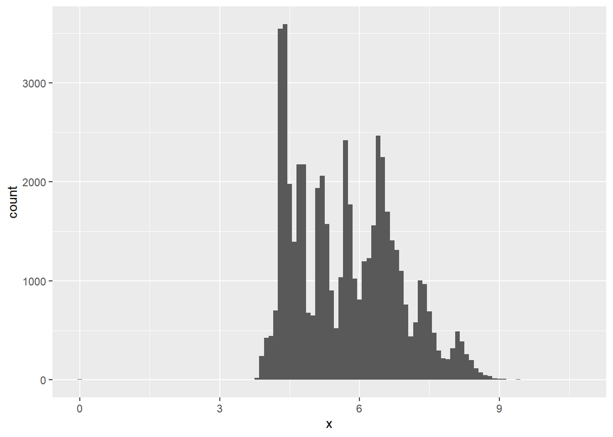

```r
diamonds |>
  ggplot(mapping = aes(x = x)) +
    geom_histogram(binwidth = 0.1)     #histogram of "x"
```

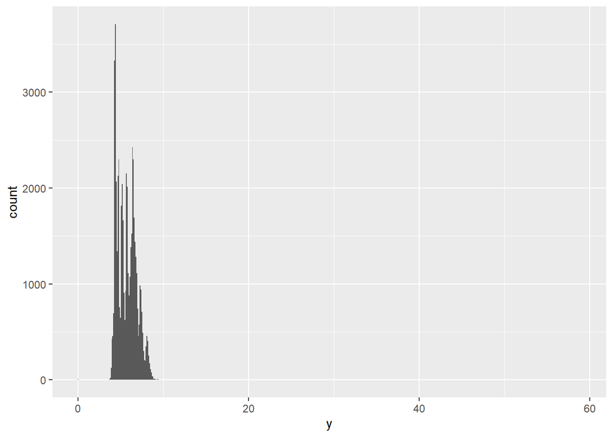

```r
diamonds |>
  ggplot(mapping = aes(x = y)) +
    geom_histogram(binwidth = 0.1)     #histogram of "y"
```

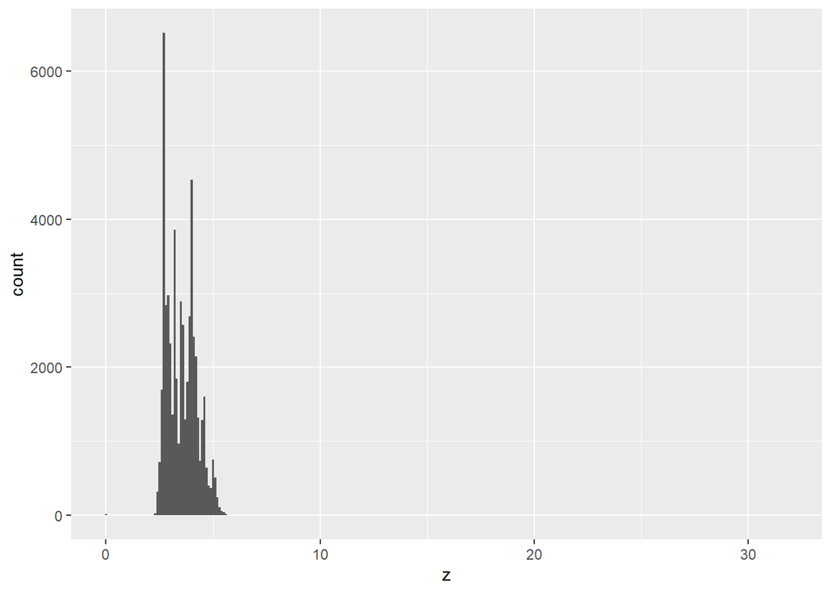

```r
diamonds |>
  ggplot(mapping = aes(x = z)) +
    geom_histogram(binwidth = 0.1)     #histogram of "z"
```

```r
# 1. x and y are larger than z,
# 2. there are outliers,
# 3. they are all right skewed, and
# 4. they are multimodal or “spiky”.

diamonds |>
  filter(x == 0 | y == 0 | z == 0)     #filter observations with value 0
```

```
## # A tibble: 20 × 10
##    carat cut       color clarity depth table price     x     y     z
##    <dbl> <ord>     <ord> <ord>   <dbl> <dbl> <int> <dbl> <dbl> <dbl>
##  1  1    Premium   G     SI2      59.1    59  3142  6.55  6.48     0
##  2  1.01 Premium   H     I1       58.1    59  3167  6.66  6.6      0
##  3  1.1  Premium   G     SI2      63      59  3696  6.5   6.47     0
##  4  1.01 Premium   F     SI2      59.2    58  3837  6.5   6.47     0
##  5  1.5  Good      G     I1       64      61  4731  7.15  7.04     0
##  6  1.07 Ideal     F     SI2      61.6    56  4954  0     6.62     0
##  7  1    Very Good H     VS2      63.3    53  5139  0     0        0
##  8  1.15 Ideal     G     VS2      59.2    56  5564  6.88  6.83     0
##  9  1.14 Fair      G     VS1      57.5    67  6381  0     0        0
## 10  2.18 Premium   H     SI2      59.4    61 12631  8.49  8.45     0
## 11  1.56 Ideal     G     VS2      62.2    54 12800  0     0        0
## 12  2.25 Premium   I     SI1      61.3    58 15397  8.52  8.42     0
## 13  1.2  Premium   D     VVS1     62.1    59 15686  0     0        0
## 14  2.2  Premium   H     SI1      61.2    59 17265  8.42  8.37     0
## 15  2.25 Premium   H     SI2      62.8    59 18034  0     0        0
## 16  2.02 Premium   H     VS2      62.7    53 18207  8.02  7.95     0
## 17  2.8  Good      G     SI2      63.8    58 18788  8.9   8.85     0
## 18  0.71 Good      F     SI2      64.1    60  2130  0     0        0
## 19  0.71 Good      F     SI2      64.1    60  2130  0     0        0
## 20  1.12 Premium   G     I1       60.4    59  2383  6.71  6.67     0
```

```r
# Zero = missing values?

diamonds |>
  arrange(desc(y)) |>
  slice_head(n = 6)
```

```
## # A tibble: 6 × 10
##   carat cut     color clarity depth table price     x     y     z
##   <dbl> <ord>   <ord> <ord>   <dbl> <dbl> <int> <dbl> <dbl> <dbl>
## 1  2    Premium H     SI2      58.9    57 12210  8.09 58.9   8.06
## 2  0.51 Ideal   E     VS1      61.8    55  2075  5.15 31.8   5.12
## 3  5.01 Fair    J     I1       65.5    59 18018 10.7  10.5   6.98
## 4  4.5  Fair    J     I1       65.8    58 18531 10.2  10.2   6.72
## 5  4.01 Premium I     I1       61      61 15223 10.1  10.1   6.17
## 6  4.01 Premium J     I1       62.5    62 15223 10.0   9.94  6.24
```

```r
diamonds |>
  arrange(desc(z)) |>
  slice_head(n = 6)
```

```
## # A tibble: 6 × 10
##   carat cut       color clarity depth table price     x     y     z
##   <dbl> <ord>     <ord> <ord>   <dbl> <dbl> <int> <dbl> <dbl> <dbl>
## 1  0.51 Very Good E     VS1      61.8  54.7  1970  5.12  5.15 31.8
## 2  2    Premium   H     SI2      58.9  57   12210  8.09 58.9   8.06
## 3  5.01 Fair      J     I1       65.5  59   18018 10.7  10.5   6.98
## 4  4.5  Fair      J     I1       65.8  58   18531 10.2  10.2   6.72
## 5  4.13 Fair      H     I1       64.8  61   17329 10     9.85  6.43
## 6  3.65 Fair      H     I1       67.1  53   11668  9.53  9.48  6.38
```

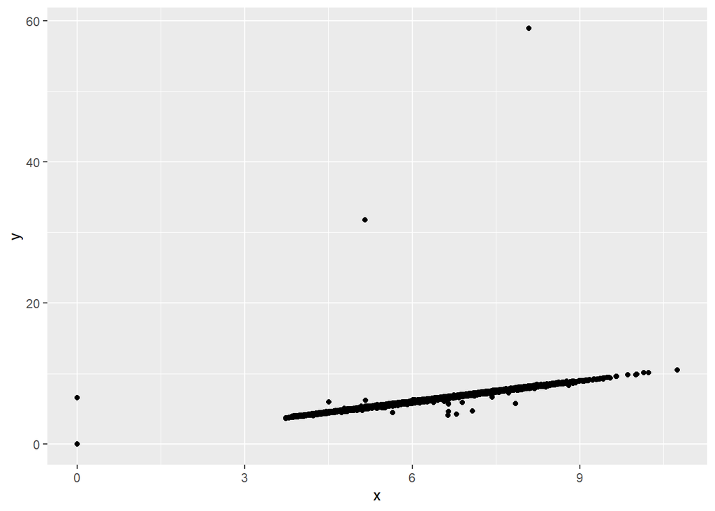

```r
# Data errors?

ggplot(diamonds, aes(x = x, y = y)) +
  geom_point()
```

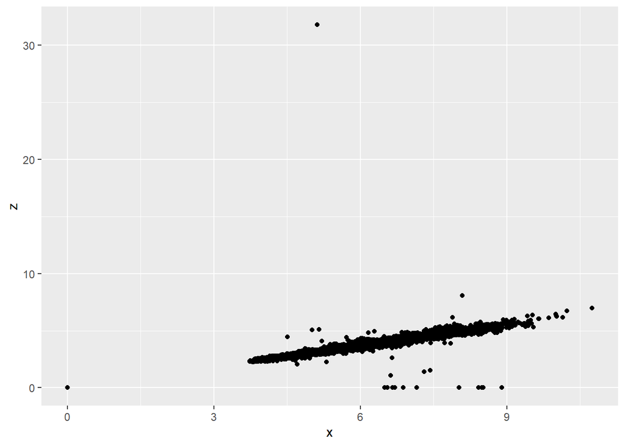

```r
ggplot(diamonds, aes(x = x, y = z)) +
  geom_point()
```

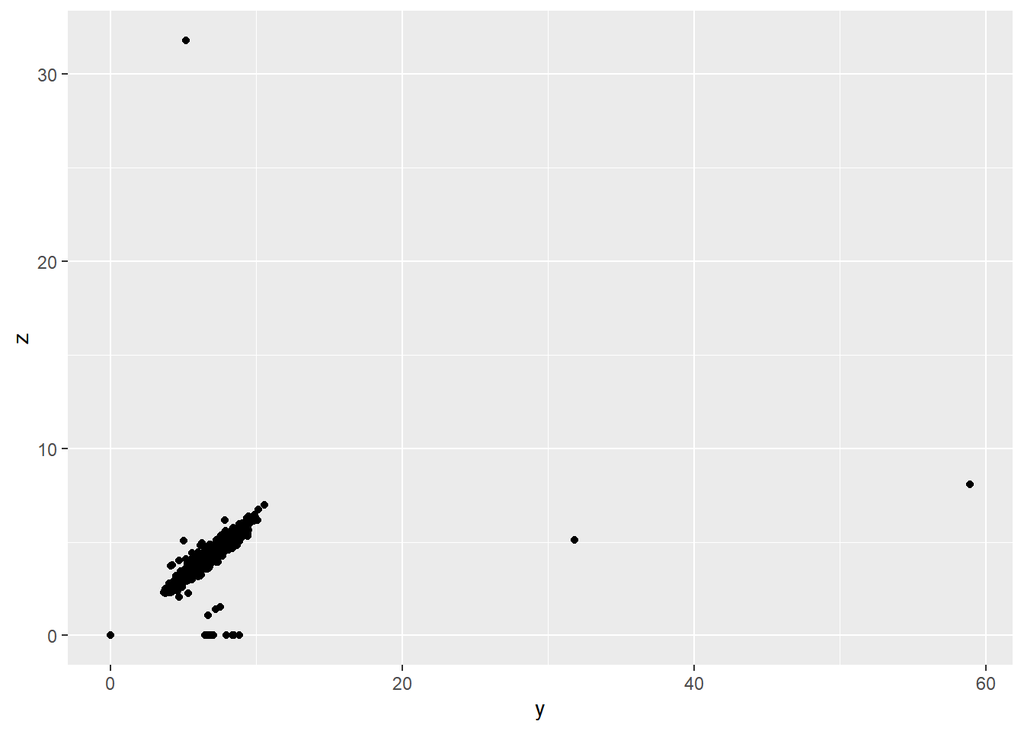

```r
ggplot(diamonds, aes(x = y, y = z)) +
  geom_point()
```

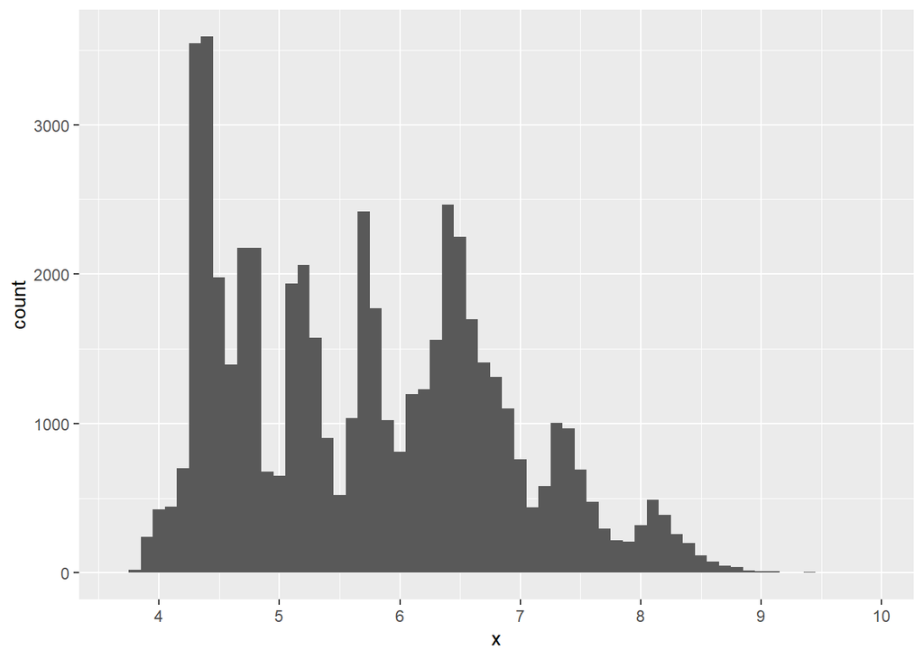

```r
# Clear outliers

diamonds |>
  filter(x > 0, x < 10) |>             #filter out unusual observations
  ggplot(aes(x = x)) +
  geom_histogram(binwidth = 0.1) +
  scale_x_continuous(breaks = 1:10)
```

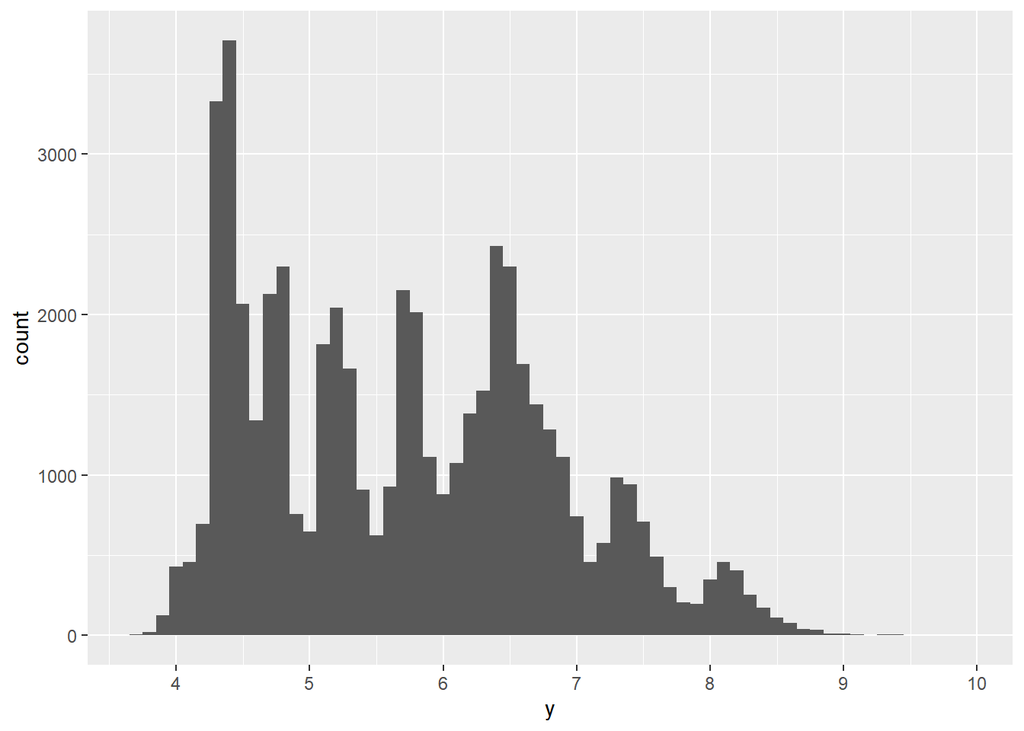

```r
diamonds |>
  filter(y > 0, y < 10) |>             #filter out unusual observations
  ggplot(aes(x = y)) +
  geom_histogram(binwidth = 0.1) +
  scale_x_continuous(breaks = 1:10)
```

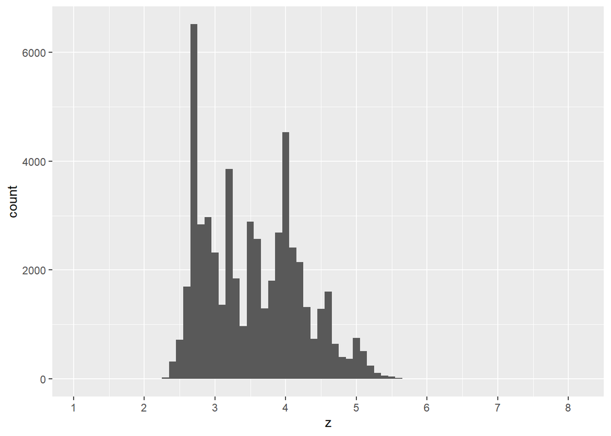

```r
diamonds |>
  filter(z > 0, z < 10) |>
  ggplot(aes(x = z)) +
  geom_histogram(binwidth = 0.1) +
  scale_x_continuous(breaks = 1:10)
```

b) Explore the distribution of price. Do you discover anything unusual or surprising? (Hint: Carefully think about the binwidth and make sure you try a wide range of values.)

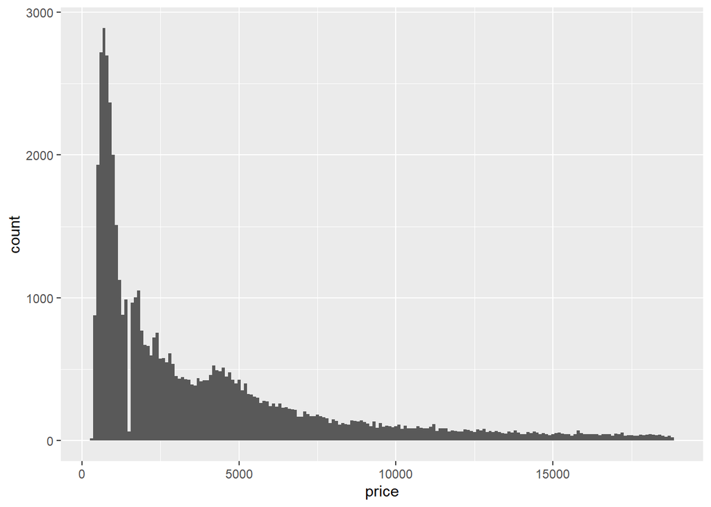

```r
ggplot(diamonds, aes(x = price)) +
  geom_histogram(binwidth = 100)
```

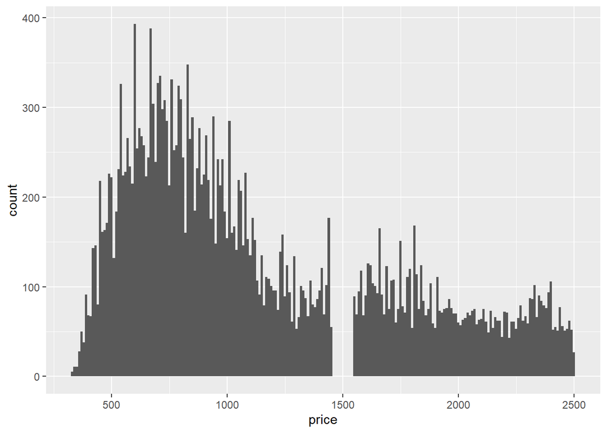

```r
diamonds |>
  filter(price < 2500) |>              #filter for observations less than 2500
  ggplot(aes(x = price)) +
  geom_histogram(binwidth = 10)
```

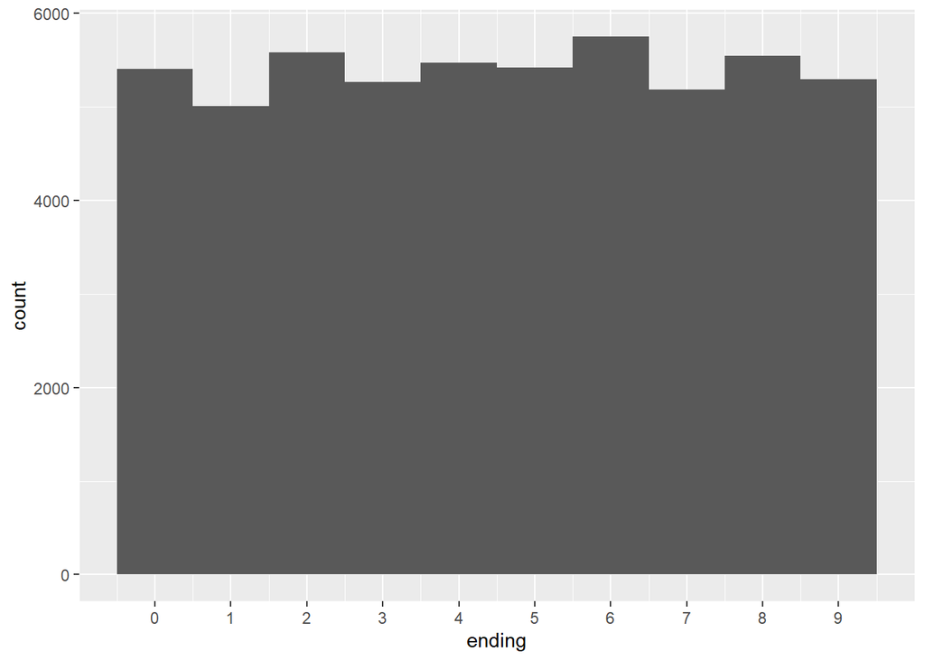

```r
# No diamonds with price $1,500
# Bulge in distribution around $750.

diamonds |>
  mutate(ending = price %% 10) |>      #calculate ending algorism of "price"
  ggplot(aes(x = ending)) +
  geom_histogram(binwidth = 1) +
  scale_x_continuous(breaks = 0:9)
```

```r
# No rounding to 5 or 0
```

c) How many diamonds are 0.99 carat? How many are 1 carat? What do you think is the cause of the difference?

```r
diamonds |>
  #filter for observations with carat of 0.99 or 1.00
  filter(carat %in% c(0.99,1)) |>
  count(carat)
```

```
## # A tibble: 2 × 2
##   carat     n
##   <dbl> <int>
## 1  0.99    23
## 2  1     1558
```

```r
# Round up to 1?
```

d) Compare and contrast coord_cartesian() vs xlim() or ylim() when zooming in on a histogram. What happens if you leave binwidth unset? What happens if you try and zoom so only half a bar shows?

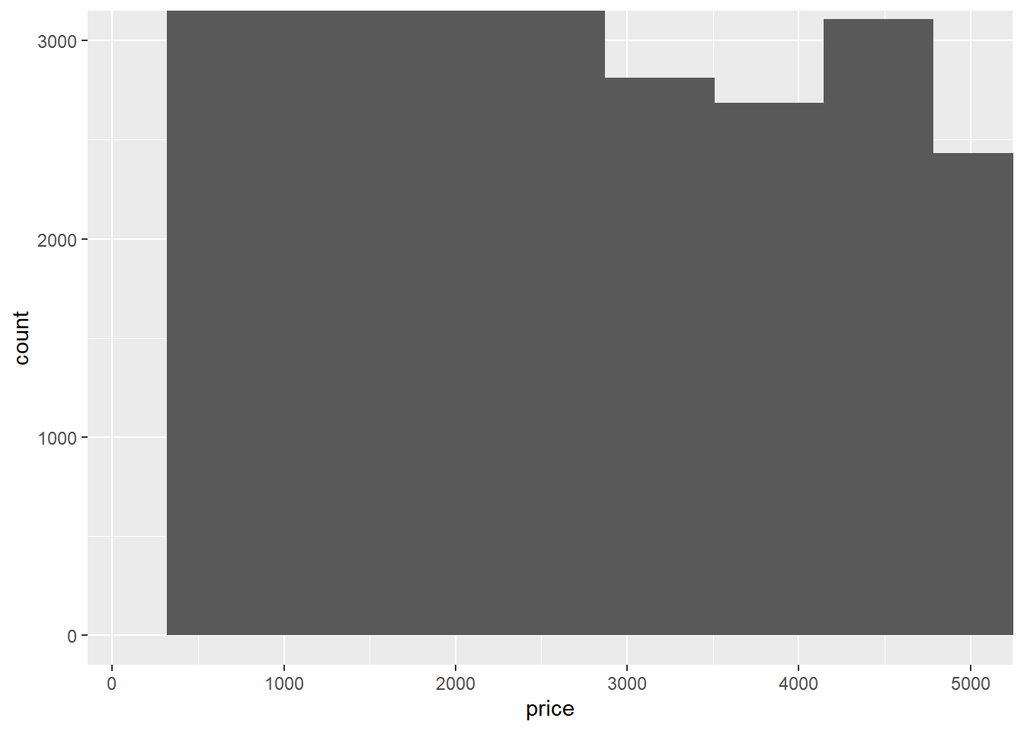

```r
ggplot(diamonds, aes(x = price)) +
  geom_histogram() +
  coord_cartesian(xlim = c(100, 5000), ylim = c(0, 3000))
```

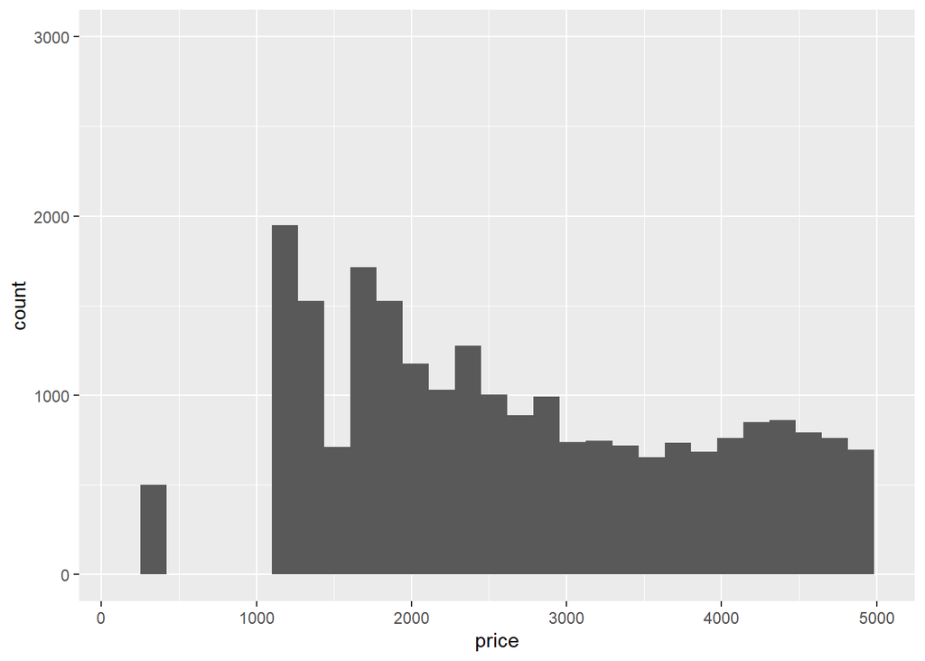

```r
ggplot(diamonds, aes(x = price)) +
  geom_histogram() +
  xlim(100, 5000) + ylim(0, 3000)
```

## 1.2. UNUSUAL VALUES

[No exercises]

# 2. MISSING VALUES

[from https://r4ds.hadley.nz/missing-values.html]

[see https://jrnold.github.io/r4ds-exercise-solutions/exploratory-data-analysis.html]

[see https://mine-cetinkaya-rundel.github.io/r4ds-solutions/EDA.html]

```r
library("nycflights13")
library("tidyverse")
```

## 2.1. EXPLICIT MISSING VALUES

a) What happens to missing values in a histogram? What happens to missing values in a bar chart? Why is there a difference?

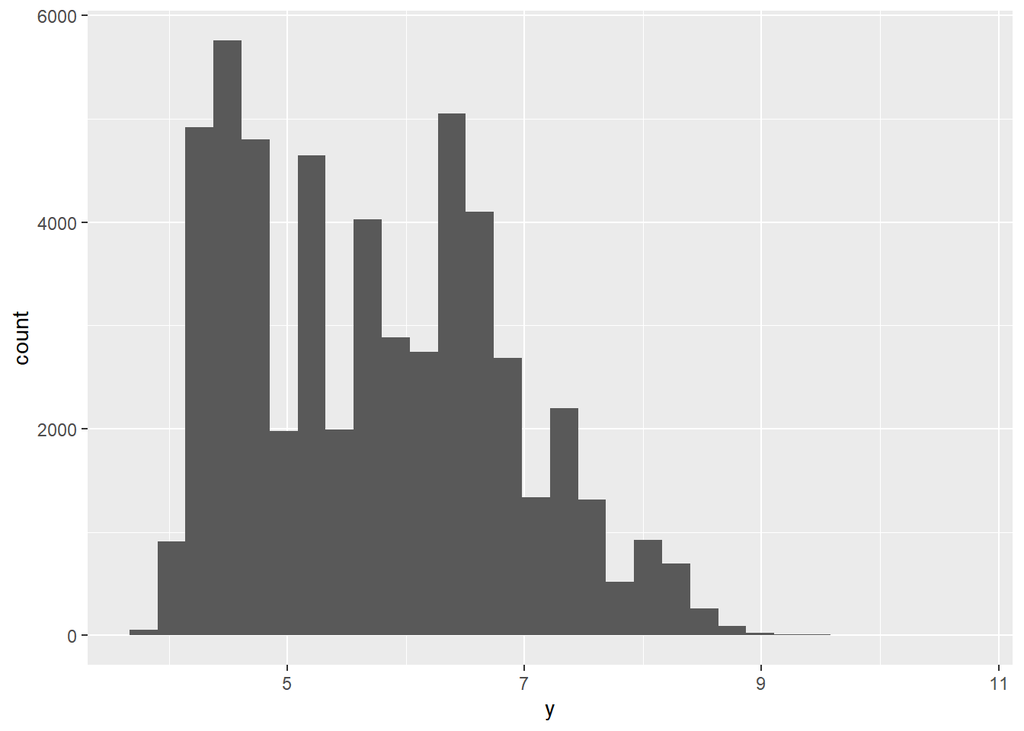

```r
diamonds |>
  mutate(y = if_else(y < 3 | y > 20, NA, y)) |>
  ggplot(aes(x = y)) +
  geom_histogram()
```

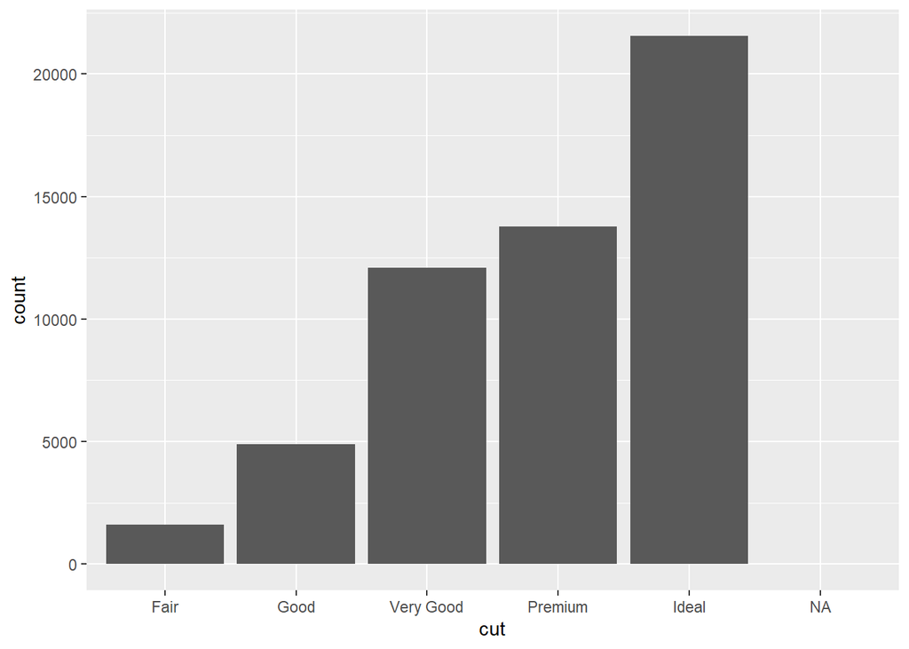

```r
diamonds |>
  mutate(cut = if_else(y < 3 | y > 20, NA, cut)) |>
  ggplot(aes(x = cut)) +
  geom_bar()
```

b) What does na.rm = TRUE do in mean() and sum()?

```r
diamonds |>
  mutate(carat = if_else(y < 3 | y > 20, NA, carat)) |>
  summarize(
    average_with_NA = mean(carat),
    average_without_NA = mean(carat, na.rm = TRUE)
  )
```

```
## # A tibble: 1 × 2
##   average_with_NA average_without_NA
##             <dbl>              <dbl>
## 1              NA              0.798
```

## 2.2. IMPLICIT MISSING VALUES

a) Can you find any relationship between the carrier and the rows that appear to be missing from planes?

```r
flights |>
  distinct(tailnum) |>                    #obtain distinct "tailnum"
  anti_join(planes)                       #obtain absent "tailnum"
```

```
## # A tibble: 722 × 1
##    tailnum
##    <chr>
##  1 N3ALAA
##  2 N3DUAA
##  3 N542MQ
##  4 N730MQ
##  5 N9EAMQ
##  6 N532UA
##  7 N3EMAA
##  8 N518MQ
##  9 N3BAAA
## 10 N3CYAA
## # ℹ 712 more rows
```

```r
flights |>
  mutate(
    absent = !tailnum %in% planes$tailnum #calculate if tailnum is absent
  ) |>
  group_by(carrier) |>                    #group by "carrier"
  summarize(n_absent = sum(absent),       #calculate number of "absent"
            n_total = n(),                #calculate number of observations
            p_absent = mean(absent)       #calculate probability of "absent"
  ) |>
  filter(n_absent > 0)
```

```
## # A tibble: 10 × 4
##    carrier n_absent n_total p_absent
##    <chr>      <int>   <int>    <dbl>
##  1 9E          1044   18460  0.0566
##  2 AA         22558   32729  0.689
##  3 B6           830   54635  0.0152
##  4 DL           110   48110  0.00229
##  5 F9            50     685  0.0730
##  6 FL           187    3260  0.0574
##  7 MQ         25397   26397  0.962
##  8 UA          1693   58665  0.0289
##  9 US           699   20536  0.0340
## 10 WN            38   12275  0.00310
```

## 2.3. FACTORS AND EMPTY GROUPS

[no exercises]